# Amazon Data Science Book Analysis

##### **Price and Reviews Correlation**

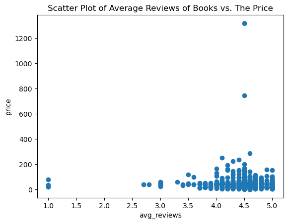

```python
#Creating scatter plot to show how the average review reflects the price of a book.
plt.scatter(df['avg_reviews'],df['price'])
plt.ylabel('price')
plt.xlabel('avg_reviews')
plt.title('Scatter Plot of Average Reviews of Books vs. The Price')
plt.show()
```

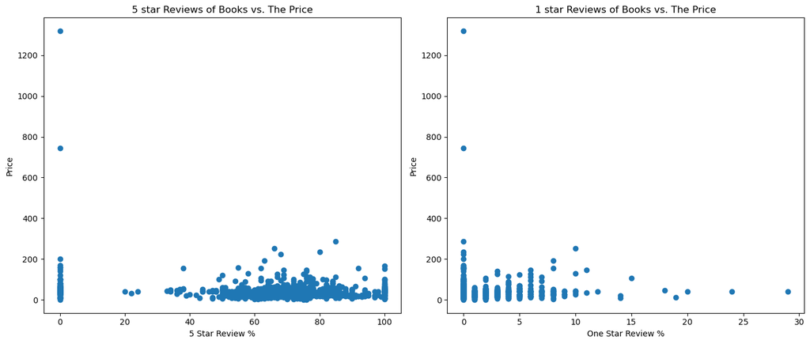

```python
#Creating scatter plots to show difference between price of five star and one star reviewed books.
fig, (ax1, ax2) = plt.subplots(1, 2, figsize=(14, 6))
ax1.scatter(df['star5']*100,df['price'])
ax1.set_ylabel('Price')
ax1.set_xlabel('5 Star Review %')
ax1.set_title('5 star Reviews of Books vs. The Price')

ax2.scatter(df['star1']* 100,df['price'])
ax2.set_ylabel('Price')
ax2.set_xlabel('One Star Review %')
ax2.set_title('1 star Reviews of Books vs. The Price')

plt.tight_layout()
plt.show()
```

```python
#Query to retrieve lowest priced books and their rating.
title_price_rating_lowest = '''
SELECT title as 'Book Name', price as 'Price in US Dollars', avg_reviews as 'Average Rating'
FROM books
ORDER BY price ASC
LIMIT 10
'''

print('Ten cheapest books with price and average rating:')
pd.read_sql_query(title_price_rating_lowest, conn)
```

```
Ten cheapest books with price and average rating:
```

|  | Book Name | Price in US Dollars | Average Rating |
| --- | --- | --- | --- |
| 0 | Python for Everybody: Exploring Data in Python 3 | 0.99 | 4.6 |
| 1 | The Dropout Multi-Millionaire: 37 Business Les... | 0.99 | 4.6 |
| 2 | Python for Passionate Beginners 2023: A Practi... | 0.99 | 4.5 |
| 3 | Naked Statistics: Stripping the Dread from the... | 1.69 | 4.6 |
| 4 | Leading a Data Driven Organization: A Practica... | 2.99 | 5.0 |
| 5 | Statistics & Statistical Analysis Illustrated:... | 3.99 | 4.1 |
| 6 | Learn Coding Basics in Hours with Python | 3.99 | 4.5 |
| 7 | The United States of America: the Superpower, ... | 3.99 | 4.4 |
| 8 | A Student's Guide to Python for Physical Model... | 4.95 | 4.5 |
| 9 | Deep Learning: A Comprehensive Guide to Python... | 4.97 | 4.7 |

```python
#Query to retrieve highest priced books and their rating.
title_price_rating_highest = '''
SELECT title as 'Book Name', price as 'Price in US Dollars', avg_reviews as 'Average Rating'
FROM books
ORDER BY price DESC
LIMIT 10
'''

print('Ten most expensive books with price and average rating:')
pd.read_sql_query(title_price_rating_highest, conn)
```

```
Ten most expensive books with price and average rating:
```

|  | Book Name | Price in US Dollars | Average Rating |
| --- | --- | --- | --- |
| 0 | Research Anthology on Machine Learning Techniq... | 1318.74 | 4.5 |
| 1 | Database Technologies: Concepts, Methodologies... | 743.47 | 4.5 |
| 2 | The Basics of Data Literacy: Helping Your Stud... | 287.14 | 4.6 |
| 3 | Statistics, Data Analysis, and Decision Modeling | 250.63 | 4.1 |
| 4 | Pharmacokinetic and Pharmacodynamic Data Analy... | 233.60 | 4.4 |
| 5 | Analytics, Data Science, & Artificial Intellig... | 223.00 | 4.3 |
| 6 | Clinical Genomics, Second Edition: A Guide to ... | 200.00 | 4.5 |
| 7 | Data Structures & Algorithm Analysis in C++ | 193.32 | 4.2 |
| 8 | Geographic Data Science with Python (Chapman &... | 170.00 | 4.5 |
| 9 | Cybersecurity Data Science: Best Practices in ... | 165.80 | 4.0 |

##### **Pages and Reviews Correlation**

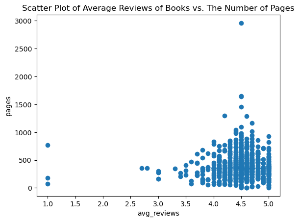

```python
#Creating scatter plot to show how number of pages and average reviews correlate with each other.
plt.scatter(df['avg_reviews'],df['pages'])
plt.ylabel('pages')
plt.xlabel('avg_reviews')
plt.title('Scatter Plot of Average Reviews of Books vs. The Number of Pages')
plt.show()
```

### **6. Conclusion**

The conclusion synthesizes the key findings, offering a cohesive summary that ties together the various aspects of the analysis. The actionable insights derived from this study include:

- For Authors: Understanding the competitive landscape and identifying niches that are less saturated.
- For Publishers: Pricing strategies based on market benchmarks and identifying high-potential authors and book characteristics that lead to higher ratings.
- For Buyers: Recommendations for top-rated and well-reviewed books to aid in informed purchasing decisions.

These insights are grounded in the data and provide clear, actionable recommendations that can be directly implemented to enhance decision-making processes for all stakeholders involved in the data science book market.

**References:**

Kaggle. (2024). Amazon Data Science Books Dataset. Retrieved from https://www.kaggle.com/datasets/die9origephit/amazon-data-science-books/data.

```python
#Code to track the number of coding lines within the notebook.
import nbformat

# Replace 'your_notebook.ipynb' with the path to your notebook file
notebook_path = 'Amazon Data Science Book Analysis.ipynb'

# Read the notebook file
with open(notebook_path, 'r', encoding='utf-8') as f:
    notebook = nbformat.read(f, as_version=4)

# Initialize line count
total_lines = 0

# Iterate through the notebook cells
for cell in notebook.cells:
    if cell.cell_type == 'code':
        code_lines = cell.source.split('\n')
        total_lines += len(code_lines)

print(f"Total number of lines of code: {total_lines}")
```

```
Total number of lines of code: 293
```